# Gene Expression and Networks

Katja Nowick and Deisy M. Gysi

# Read in data

Define your working directory (location of input and output files).

```r
setwd("~/Vorlesungen/GEvol_Networks/")
```

We will work with a dataset produced by Snyder-Mackler et al. 2018. They investigated immune responses in rhesus macaque groups. The study included several groups of macaques. Each group consistent of five individuals of different ranks. They investigated whether the immune response depends on the rank of an individual.  
RNA of blood cells from each individual was sequenced with RNA-Seq on the Illumina platform. Reads were mapped to the rhesus macaque genome and counted to obtain gene expression data in form of raw counts per gene. We will use that dataset to calculate differential gene expression and co-expression networks. For the network, we will focus on transcription factor (TF) genes.

Read in your expression data, i.e. a count matrix and the metadata, which will be stored in the variables readcounts and coldata, respectively.

```r
readcounts=read.table("Tutorial_macaques_readcounts_GeneSymbols.txt", header=TRUE, row.names=1, sep="\t", stringsAsFactors=FALSE)
dim(readcounts)
```

```
## [1] 15115    50
```

```r
head(readcounts)
```

```
##           SRR3660629 SRR3660630 SRR3660632 SRR3660633 SRR3660636 SRR3660637
## 5_8S_rRNA          1         10          4          2          4          2
## 5S_rRNA           12          4          3          4          3          7
## A1BG               4          0         18         15         22         46
## A1CF              10         14         11         16          7          3
## A2ML1            193        210         64         93         54        107
## A3GALT2           37         65         29         35         14         32
##           SRR3660640 SRR3660641 SRR3660642 SRR3660643 SRR3660644 SRR3660645
## 5_8S_rRNA          0          0          1          6          5          9
## 5S_rRNA            0          5          3          2          0          0
## A1BG              12         27         21         42         37         15
## A1CF               2          3          5          3          2          7
## A2ML1             70         75         83        125         43        173
## A3GALT2            6         20         66         80         16         12
##           SRR3660646 SRR3660649 SRR3660650 SRR3660651 SRR3660652 SRR3660654
## 5_8S_rRNA          1          0          0          1          0          3
## 5S_rRNA            1          6          7          5          9          1
## A1BG              11         24         60         13         26          2
## A1CF               8         15         12         11         18         20
## A2ML1            142         92        159         69         93         91
## A3GALT2           10         17         31         22         32         38
##           SRR3660655 SRR3660659 SRR3660660 SRR3660661 SRR3660665 SRR3660666
## 5_8S_rRNA          5          1          4          0          0          0
## 5S_rRNA            0          1          2          0          2          0
## A1BG               0          0          5          0         51         69
## A1CF              19          3         14          5         10          0
## A2ML1            120         77        101         98         46         81
## A3GALT2           49          6         58         37         26         53
##           SRR3660668 SRR3660669 SRR3660670 SRR3660671 SRR3660672 SRR3660673
## 5_8S_rRNA          1          1          1          6          2         10
## 5S_rRNA            4          1          3          1          3          2
## A1BG              11          9          0          0         17          4
## A1CF               6          8          5         12          0          1
## A2ML1             34         44         58         99         36        120
## A3GALT2            6          4         22         46          8         14
##           SRR3660676 SRR3660677 SRR3660678 SRR3660679 SRR3660686 SRR3660687
## 5_8S_rRNA          2          3          4          9          5          9
## 5S_rRNA            2          4          3          2          1          0
## A1BG               5         26        112         32         57          4
## A1CF               8         20          6         11          3          9
```

[output cut: 8 more lines]

```
## A3GALT2           32         67         11          9         58         99
##           SRR3660697 SRR3660698 SRR3660699 SRR3660700 SRR3660701 SRR3660702
## 5_8S_rRNA          4          4          6          8          0          0
## 5S_rRNA            2          0          1          3          0          3
## A1BG              56         65         49         17         15         25
## A1CF               3          2          7          2          9         12
## A2ML1             48         37         35         48         82        102
## A3GALT2           85         58         18         28         87        104
##           SRR3660707 SRR3660708
## 5_8S_rRNA          2          0
## 5S_rRNA           11          2
## A1BG               9         54
## A1CF              12         36
## A2ML1            129        133
## A3GALT2           33         75
```

```r
coldata=read.table("Tutorial_macaques_ids.txt", header=TRUE, row.names=1, sep="\t", stringsAsFactors=FALSE)
dim(coldata)
```

```
## [1] 50  4
```

```r
head(coldata)
```

```
##            subject_id condition study_group rank
## SRR3660629       RAc8       LPS    VBB_SGE2    4
## SRR3660630       RAc8        NC    VBB_SGE2    4
## SRR3660632      RCw10       LPS   Cw10_SGE2    1
## SRR3660633      RCw10        NC   Cw10_SGE2    1
## SRR3660636      REg12       LPS    Fq9_SGE2    3
## SRR3660637      REg12        NC    Fq9_SGE2    3
```

Read in the TF genes

```r
TFs = read.table("TFs.txt", header=TRUE, sep="\t", stringsAsFactors=FALSE)
dim(TFs)
```

```
## [1] 1834    1
```

```r
TFs = TFs[,1]
length(TFs)
```

```
## [1] 1834
```

# Networks

## Building weighted topological overlap (wTO) networks

We will make a transcription factor (TF) wTO network for control samples (NC) and one for the treatment samples (LPS). We will only consider differentially expressed genes, which will help to reduce runtime.  
We will in the next chapter compare these two wTO networks using CoDiNA. Load the wTO package.

```r
require(wTO)
require(magrittr)
```

### Splitting the input file into one for control (NC) and one for treatment (LPS)

First, collecting all NC samples:

```r
NC = readcounts[,coldata$condition == 'NC']
dim(NC)
```

```
## [1] 15115    25
```

Removing genes that have less than 10 counts:

```r
NC = NC[rowSums(NC)> 10,]
dim(NC)
```

```
## [1] 11432    25
```

Then, collecting all LPS samples and removing genes that have less than 10 counts:

```r
LPS = readcounts[,coldata$condition == 'LPS']
dim(LPS)
```

```
## [1] 15115    25
```

```r
LPS = LPS[rowSums(LPS)> 10,]
dim(LPS)
```

```
## [1] 11444    25
```

You could now start building the two networks, e.g. one for NC and one for LPS. But this would take a bit too long for this tutorial if we used all the expressed genese. We will thus reduce our dataset to only the differentially expressed genes. To find the DE genes, i.e. differentially expressed between NC and LPS, we will use DESeq2.

## DESeq

DESeq2 is based on a model using the negative binomial distribution. Install it if necessary. To install the DESeq2 library use: if (!require(“BiocManager”, quietly = TRUE)) install.packages(“BiocManager”) BiocManager::install(“DESeq2”)

Load the library DESeq2

```r
library("DESeq2")
```

The conditions treatment vs. control (LPS vs. NC) need to be defined as factors for the comparison. The reference (control) in this example is “NC”.

```r
coldata$condition = factor(coldata$condition)
```

Make a DESeqDataSet object and look at it. It will hold the count information for each gene for each sample.

```r
dds=DESeqDataSetFromMatrix(countData = readcounts, colData = coldata, design = ~ condition)
dds
```

```
## class: DESeqDataSet
## dim: 15115 50
## metadata(1): version
## assays(1): counts
## rownames(15115): 5_8S_rRNA 5S_rRNA ... ZYX ZZEF1
## rowData names(0):
## colnames(50): SRR3660629 SRR3660630 ... SRR3660707 SRR3660708
## colData names(4): subject_id condition study_group rank
```

Filter genes with very low expression to reduce noise. Here we will remove all genes with lower than 10 reads in total across all samples.

```r
keep = rowSums(counts(dds)) >= 10
dds = dds[keep,]
dds
```

```
## class: DESeqDataSet
## dim: 12062 50
## metadata(1): version
## assays(1): counts
## rownames(12062): 5_8S_rRNA 5S_rRNA ... ZYG11A ZYG11B
## rowData names(0):
## colnames(50): SRR3660629 SRR3660630 ... SRR3660707 SRR3660708
## colData names(4): subject_id condition study_group rank
```

To specify the factors for the comparison use the function factor(). In this first example, we will compare NC vs. LPS.

```r
dds$condition = factor(dds$condition, levels = c("NC","LPS"))
```

### Differential expression analysis

The function DESeq() implements all steps from normalization to the comparison: The first step is always normalization. It estimates the effective library size to normalize for it (estimateSizeFactors). Imagine, a gene has the same number of counts in two samples, but the library size (total number of reads) was twice as high in the first sample. Then we would conclude that the gene was higher expressed in the second sample.  
The core assumption for calculating the dispersion (estimateDispersions) is that the mean is a good predictor of the variance, i.e., that genes with a similar expression level also have similar variance across replicates.  
Then differential expression will be calculated using the (default) Wald test. This is followed by (per default) Benjamini-Hochberg adjustment of p-values.  
Takes less than one minute.

```r
dds = DESeq(dds)
```

```
## -- replacing outliers and refitting for 80 genes
## -- DESeq argument 'minReplicatesForReplace' = 7
## -- original counts are preserved in counts(dds)
```

```r
result = results(dds)
result
```

```
## log2 fold change (MLE): condition LPS vs NC
## Wald test p-value: condition LPS vs NC
## DataFrame with 12062 rows and 6 columns
##             baseMean log2FoldChange     lfcSE      stat    pvalue      padj
##            <numeric>      <numeric> <numeric> <numeric> <numeric> <numeric>
## 5_8S_rRNA    3.21412      -0.486586  0.435680 -1.116841 0.2640621  0.718323
## 5S_rRNA      2.88154       0.288928  0.413668  0.698453 0.4848937  0.871836
## A1BG        23.41576       0.359593  0.494143  0.727710 0.4667910  0.865984
## A1CF         8.13357      -0.117368  0.295288 -0.397468 0.6910222  0.940748
## A2ML1       89.11929      -0.256881  0.136761 -1.878318 0.0603376  0.345135
## ...              ...            ...       ...       ...       ...       ...
## ZW10       665.34750     -0.3366889 0.2621427  -1.28437 0.1990117  0.648563
## ZWILCH       7.30413      0.6106206 0.3346090   1.82488 0.0680194  0.372095
## ZXDC        10.22030     -0.3800419 0.3077976  -1.23471 0.2169371  0.668658
## ZYG11A    1068.82936     -0.0562768 0.0784543  -0.71732 0.4731766  0.868994
## ZYG11B     865.26162     -0.1745405 0.1313379  -1.32894 0.1838671  0.627037
```

To display what the column names mean use:

```r
mcols(result)$description
```

```
## [1] "mean of normalized counts for all samples"
## [2] "log2 fold change (MLE): condition LPS vs NC"
## [3] "standard error: condition LPS vs NC"
## [4] "Wald statistic: condition LPS vs NC"
## [5] "Wald test p-value: condition LPS vs NC"
## [6] "BH adjusted p-values"
```

Summary of the results:

```r
summary(result)
```

```
##
## out of 12061 with nonzero total read count
## adjusted p-value < 0.1
## LFC > 0 (up)       : 729, 6%
## LFC < 0 (down)     : 346, 2.9%
## outliers [1]       : 0, 0%
## low counts [2]     : 1171, 9.7%
## (mean count < 1)
## [1] see 'cooksCutoff' argument of ?results
## [2] see 'independentFiltering' argument of ?results
```

Ordering of the results by adjusted p-value and picking the most significant genes. Here we will count how many genes have an adjusted p-value of smaller than 0.1 or 0.05, respectively.

```r
resultOrdered = result[order(result$pvalue),]
sum(result$padj < 0.1, na.rm=TRUE)
```

```
## [1] 1075
```

```r
sum(result$padj < 0.05, na.rm=TRUE)
```

```
## [1] 837
```

We can now select only the significant genes from the tables with LPS and NC samples:

```r
DE_genes = subset(row.names(result), result$padj<0.01)
NC = subset(NC, row.names(NC) %in% DE_genes)
LPS = subset(LPS, row.names(LPS) %in% DE_genes)
```

### Constructing the networks

Now we have gathered all information to construct the networks. wTO performs a bootstrapping analysis to evaluate how likely it is that an inferred link is real. Note, that in a real analysis, you should run 1000 bootstraps, i.e. n should be 1000. Here we will run it only with n=10 to save time.

#### First, constructing the NC network

```r
network_NC_obj = wTO.Complete(n = 10, k = 5,  Data = NC,
                          method_resampling = 'Bootstrap',
                          Overlap = TFs, method = 's', plot = T)
```

```
## There are 46 overlapping nodes, 569 total nodes and 25 individuals.
```

```
## This function might take a long time to run. Don't turn off the computer.
```

```
## Simulations are done.
```

```
## Computing p-values
```

```
## Computing cutoffs
```

```
## Done!
```

```r
network_NC_obj
```

```
## $wTO
##       Node.1 Node.2 wTO_sign wTO_abs pval_sig pval_abs  Padj_sig Padj_abs
##    1:  AHDC1  BAZ2A    0.292   0.334      0.2      0.0 0.3723022      0.0
##    2:  AHDC1  BCL6B    0.113   0.168      0.7      0.3 0.7000000      0.3
##    3:  AHDC1  DOT1L    0.376   0.442      0.2      0.0 0.3723022      0.0
##    4:  AHDC1   E2F1    0.188   0.244      0.2      0.0 0.3723022      0.0
##    5:  AHDC1   E2F6    0.120   0.220      0.4      0.0 0.4830805      0.0
##   ---
## 1031: ZNF595 ZNF711    0.245   0.292      0.4      0.0 0.4830805      0.0
## 1032: ZNF595 ZNF841   -0.544   0.568      0.0      0.0 0.0000000      0.0
## 1033: ZNF641 ZNF711   -0.419   0.479      0.5      0.0 0.5329557      0.0
## 1034: ZNF641 ZNF841    0.590   0.594      0.0      0.0 0.0000000      0.0
## 1035: ZNF711 ZNF841   -0.454   0.489      0.5      0.0 0.5329557      0.0
##
## $Correlation
## NULL
##
## $Quantiles
##                         0.1%  2.5%   10%  90% 97.5% 99.9%
## Empirical.Quantile     -0.63 -0.48 -0.30 0.56  0.64  0.69
## Quantile               -0.56 -0.47 -0.26 0.54  0.60  0.62
## Empirical.Quantile.abs  0.19  0.23  0.27 0.58  0.65  0.69
## Quantile.abs            0.16  0.18  0.23 0.56  0.60  0.63
##
## attr(,"class")
## [1] "wTO"  "list"
```

[figure not shown]

You can look at the diagnostic plots produced by the wTO.Complete function, to get a feeling for the distribution of wTO values and p-values in your network. This can be helpful to decide on a cutoff for plotting or further analysis.

Selecting the table with the information on nodes, wTO and p-values:

```r
network_NC = network_NC_obj$wTO
head(network_NC)
```

```
##    Node.1 Node.2 wTO_sign wTO_abs pval_sig pval_abs  Padj_sig Padj_abs
## 1:  AHDC1  BAZ2A    0.292   0.334      0.2      0.0 0.3723022      0.0
## 2:  AHDC1  BCL6B    0.113   0.168      0.7      0.3 0.7000000      0.3
## 3:  AHDC1  DOT1L    0.376   0.442      0.2      0.0 0.3723022      0.0
## 4:  AHDC1   E2F1    0.188   0.244      0.2      0.0 0.3723022      0.0
## 5:  AHDC1   E2F6    0.120   0.220      0.4      0.0 0.4830805      0.0
## 6:  AHDC1   ELF2    0.333   0.377      0.2      0.0 0.3723022      0.0
```

If the weight of the link is insignificant (i.e. probably just by chance), set wTO to zero.

```r
network_NC$wTO = ifelse(network_NC$Padj_sig<0.05, network_NC$wTO_sign, 0 )
head(network_NC)
```

```
##    Node.1 Node.2 wTO_sign wTO_abs pval_sig pval_abs  Padj_sig Padj_abs wTO
## 1:  AHDC1  BAZ2A    0.292   0.334      0.2      0.0 0.3723022      0.0   0
## 2:  AHDC1  BCL6B    0.113   0.168      0.7      0.3 0.7000000      0.3   0
## 3:  AHDC1  DOT1L    0.376   0.442      0.2      0.0 0.3723022      0.0   0
## 4:  AHDC1   E2F1    0.188   0.244      0.2      0.0 0.3723022      0.0   0
## 5:  AHDC1   E2F6    0.120   0.220      0.4      0.0 0.4830805      0.0   0
## 6:  AHDC1   ELF2    0.333   0.377      0.2      0.0 0.3723022      0.0   0
```

From the output table, remove everything but the info on nodes and the wTO between two nodes.

```r
network_NC = network_NC[,c(1:2,9)] %>% as.data.frame()
head(network_NC)
```

```
##   Node.1 Node.2 wTO
## 1  AHDC1  BAZ2A   0
## 2  AHDC1  BCL6B   0
## 3  AHDC1  DOT1L   0
## 4  AHDC1   E2F1   0
## 5  AHDC1   E2F6   0
## 6  AHDC1   ELF2   0
```

#### Second, constructing the LPS network accordingly

```r
network_LPS_obj = wTO.Complete(n = 10,  Data = LPS,
                           method_resampling = 'Bootstrap',
                           Overlap = TFs, method = 's', plot = T)
```

```
## There are 46 overlapping nodes, 578 total nodes and 25 individuals.
```

```
## This function might take a long time to run. Don't turn off the computer.
```

```
## Simulations are done.
```

```
## Computing p-values
```

```
## Computing cutoffs
```

```
## Done!
```

```r
network_LPS =network_LPS_obj$wTO
network_LPS$wTO = ifelse(network_LPS$Padj_sig <0.05, network_LPS$wTO_sign, 0 )

network_LPS = network_LPS[,c(1,2,9)] %>% as.data.frame()

head(network_LPS)
```

```
##   Node.1 Node.2   wTO
## 1  AHDC1  BAZ2A 0.569
## 2  AHDC1  BCL6B 0.000
## 3  AHDC1  DOT1L 0.612
## 4  AHDC1   E2F1 0.527
## 5  AHDC1   E2F6 0.531
## 6  AHDC1   ELF2 0.611
```

```r
head(network_NC)
```

```
##   Node.1 Node.2 wTO
## 1  AHDC1  BAZ2A   0
## 2  AHDC1  BCL6B   0
## 3  AHDC1  DOT1L   0
## 4  AHDC1   E2F1   0
## 5  AHDC1   E2F6   0
## 6  AHDC1   ELF2   0
```

[figure not shown]

Look at the distribution of wTO values in the LPS and NC network using a histogram.

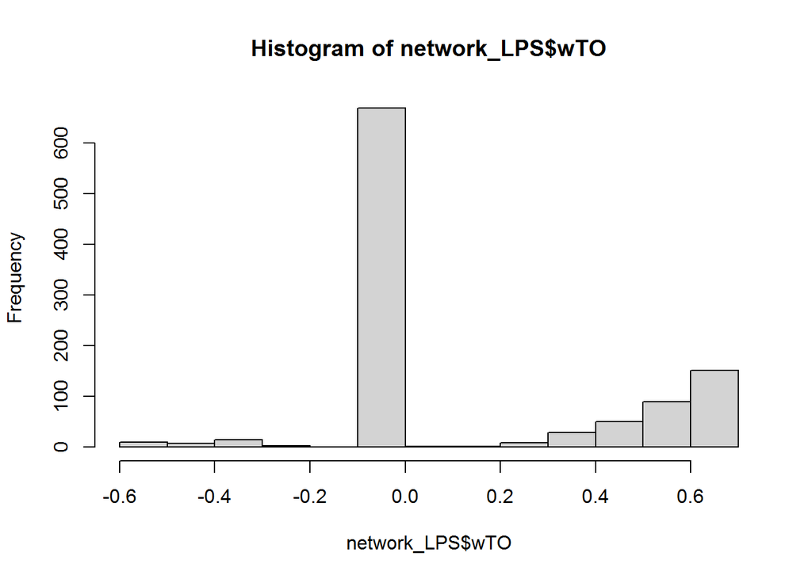

```r
hist(network_LPS$wTO)
```

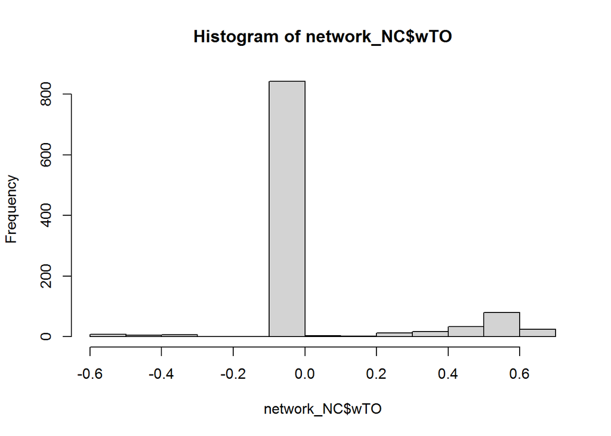

```r
hist(network_NC$wTO)
```

### Plotting the networks

We use the function NetVis on our network object. Here we set the cutoff to only plot links with wTO-values higher 0.5 or lower -0.5. You will see a network visualization appearing as an interactive plot. You can click on nodes and links to see their annotation, drag nodes, and mark selected nodes.

```r
NetVis(Node.1 = network_NC_obj$wTO$Node.1, Node.2 = network_NC_obj$wTO$Node.2,
        wTO = network_NC_obj$wTO$wTO_sign,
        cutoff = list(kind = "Threshold", value = 0.50))
```

```
## $Nodes
##         id group degree
## 1    AHDC1     1      1
## 2    BAZ2A     1     13
## 3    DOT1L     1     14
## 4     ELF2     1      1
## 5   GATAD1     1      2
## 6   HOXC10     1     21
## 7     LHX3     1      2
## 8     MBD3     1     16
## 9    MESP2     1     17
## 10   MYOD1     1     14
## 11   NPAS2     1      8
## 12  POU6F2     1      4
## 13   RBM22     1     10
```

[output cut: 18 more lines]

```r
NetVis(Node.1 = network_LPS_obj$wTO$Node.1, Node.2 = network_LPS_obj$wTO$Node.2,
        wTO = network_LPS_obj$wTO$wTO_sign,
        cutoff = list(kind = "Threshold", value = 0.50))
```

```
## $Nodes
##        id group degree
## 1   AHDC1     1     23
## 2   BAZ2A     1     19
## 3   DOT1L     1     27
## 4    E2F1     1     22
## 5    E2F6     1     18
## 6    ELF2     1     23
## 7   ESRRG     1     16
## 8   GATA6     1      6
## 9  GATAD1     1     26
## 10 HOXC10     1     30
## 11  KLF11     1     28
## 12   LHX3     1     17
## 13   MBD3     1     27
```

[output cut: 23 more lines]

We can also mark certain nodes with different shapes, e.g. GATA6 and MYOD1 by a triangle. Or, allow manipulations of the network by adding or deleting nodes and links.

```r
NetVis(Node.1 = network_LPS_obj$wTO$Node.1, Node.2 = network_LPS_obj$wTO$Node.2,
  wTO = network_LPS_obj$wTO$wTO_sign,
  pval = network_LPS_obj$wTO$pval_sign,
  padj = network_LPS_obj$wTO$pval_sign,
  cutoff= list(kind = "Threshold", value = 0.5),legend = FALSE,
  manipulation = TRUE,
  shape = list(shape = "triangle", names = c("GATA6", "MYOD1")))
```

```
## $Nodes
##        id group degree
## 1   AHDC1     1     23
## 2   BAZ2A     1     19
## 3   DOT1L     1     27
## 4    E2F1     1     22
## 5    E2F6     1     18
## 6    ELF2     1     23
## 7   ESRRG     1     16
## 8   GATA6     1      6
## 9  GATAD1     1     26
## 10 HOXC10     1     30
## 11  KLF11     1     28
## 12   LHX3     1     17
## 13   MBD3     1     27
```

[output cut: 23 more lines]

### Exporting the networks

You might want to export your network to visualize or further analyze it with other tools, e.g. Cytoscape. Here we export both networks, selecting only the significant links. The output is a table, in which the first two columns represent the link by the two nodes, followed by columns for the wTO value, p-value and adjusted p-value.

```r
wTO.export(network_NC_obj, "network_NC.txt", sign = TRUE, pvalue = 0.05, padj = 0.05, prop.NA = 0.5)
wTO.export(network_LPS_obj, "network_LPS.txt", sign = TRUE, pvalue = 0.05, padj = 0.05, prop.NA = 0.5)
```

## Comparing networks with CoDiNA

We will now compare the TF wTO networks for NC and LPS. Load the CoDiNA package.

```r
require(CoDiNA)
```

The function MakeDiffNet for comparing networks needs a list of the networks to be compared and the Code (= the name of each network). The node names need to be converted to characters before.

```r
network_NC$Node.1 = as.character(network_NC$Node.1)
network_NC$Node.2 = as.character(network_NC$Node.2)

Diff_LPS_NC = MakeDiffNet(Data = list(network_NC, network_LPS),
                          Code = c('NC', 'LPS'))
```

```
## Starting now.
```

```
## NC contains 1035 edges and 46 nodes.
```

```
## LPS contains 1035 edges and 46 nodes.
```

```
## Total of nodes: 46
```

```
## Total of edges: 1035
```

```
## Coding correlations.
```

```
## Total of edges (inside the cutoff): 449
```

```
## Starting Phi categorization.
```

```
## Coding the groups.
```

```
## Recode is done!
```

The resulting object, Diff_LPS_NC contains the information on the number of nodes and links in the differential network. It also contains the category of each link, it’s subcategory and the scores. To look at the table with that information, you can use the function View().

```r
Diff_LPS_NC
```

```
## Nodes 46
## Links 449
```

```r
View(Diff_LPS_NC)
```

We can filter the data for the well-assigned AND strong links. These are links with a high ratio of the two scores, Phi_tilde and internal. Phi_tilde is a measure for how central a link is. Links closer to the center of the cube are weaker than links closer to the edges. The internal score measures the distance from the link weights $\rho_{ij, k}$ to their categorical weights $\widetilde\rho_{ij, k}$. In other words, in a 3-networks comparison, if a link is considered an alpha with positive links in all networks (1,1,1), we calculate its distance to the point (1,1,1). A beta link that has a $\tilde\rho$ of $\left(1,1,-1\right)$ has its distance calculated to the point $\left(1,1,-1\right)$. And for a gamma link with $\tilde\rho$ of (0,1,1) the distance is calculated to (0,1,1). This score allows us to identify links that are most well classified into a particular phi_tilde category.

```r
Diff_LPS_NC_clean = subset(Diff_LPS_NC,
                           Diff_LPS_NC$Score_Phi_tilde/Diff_LPS_NC$Score_internal > 1)
Diff_LPS_NC_clean
```

```
## Nodes 40
## Links 359
```

### Classifying the nodes (genes) of the differential network

The function ClusterNodes() needs three parameters:  
The cleaned network (i.e. the network after the filtering above),  
The external cutoff (i.e. the minimum value for the Score_Phi_tilde; the closer you set this cutoff to one, the less nodes you will get),  
and the internal cutoff (i.e. the minimum value for the Score_internal; the closer you set this cutoff to zero, the less nodes you will get).  
Because our network is already filtered, we can use the external value as 0, and the internal as 1. This will make all nodes of the clean network to be clustered.

```r
DiffNodes = ClusterNodes(Diff_LPS_NC_clean,
                         cutoff.external = 0,
                         cutoff.internal = 1)
DiffNodes
```

```
##      Node Phi     pval_Phi Group_pval_Phi Phi_tilde pval_Phi_Tilde
## 1   AHDC1   g 1.620014e-06              g     g.LPS   1.026188e-10
## 2   BAZ2A   g 2.013675e-02              g         U   4.493290e-01
## 3   BCL6B   U 3.173105e-01              g         U   3.678794e-01
## 4   DOT1L   U 7.054570e-01              g         U   1.737739e-01
## 5    E2F1   g 4.592834e-06              g     g.LPS   1.727486e-07
## 6    E2F6   g 6.334248e-05              g     g.LPS   1.125352e-07
## 7    ELF2   g 2.747268e-04              g     g.LPS   9.836489e-06
## 8   ESRRG   g 6.334248e-05              g     g.LPS   1.873879e-06
## 9   GATA6   g 2.699796e-03              g     g.LPS   1.234098e-04
## 10 GATAD1   g 4.592834e-06              g     g.LPS   7.582560e-10
## 11   HEY1   U 3.173105e-01              g         U   3.678794e-01
## 12 HOXC10   U 1.779317e-01              g         U   9.697197e-02
## 13  KLF11   g 1.620014e-06              g     g.LPS   1.026188e-10
## 14   LHX3   g 9.633570e-07              g     g.LPS   3.775135e-11
```

[output cut: 67 more lines]

Representing results as barplot:

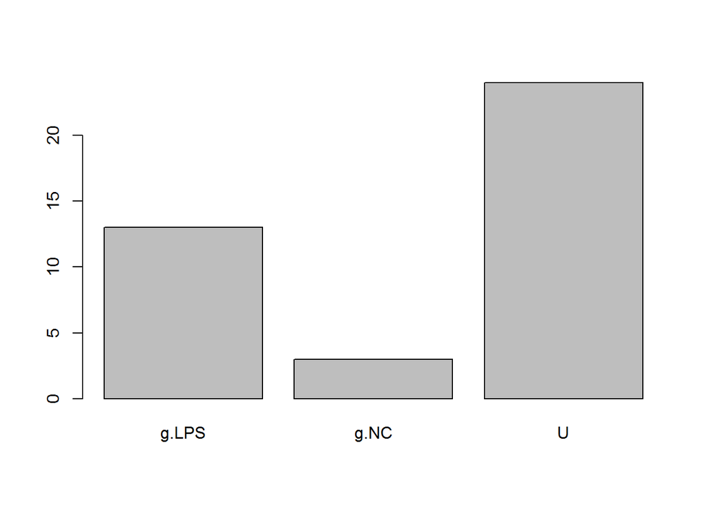

```r
barplot(table(DiffNodes$Phi_tilde))
```

We can now plot the CoDiNA network. In this tutorial, the information used for making the plot is not printed. But it should show up on your screen. Also the network should show up as an interactive plot. You can click on the links and nodes to see the GeneSymbol or filter for node categories.

```r
plot(Diff_LPS_NC_clean, layout = 'layout_with_drl')
```

If you see just a hairball, filter network before plotting. You can play around with the numbers for the external and internal cutoffs until you are satisfied with the number of nodes and links plotted. You should also see from the numbers on your screen that your network has fewer nodes and links.

```r
plot(Diff_LPS_NC_clean,
     cutoff.external = 0.8,
     cutoff.internal = 0.3,
     layout = 'layout_with_drl')
```

### Extracting information about nodes (genes) of each category

We can, for instance, subset for the common (alpha) nodes and for the nodes specific (gamma) to each network. The resulting information will be saved to a file.

```r
common_genes = subset(DiffNodes$Node, DiffNodes$Phi_tilde == 'a')
LPS_genes = subset(DiffNodes$Node, DiffNodes$Phi_tilde == 'g.LPS')
NC_genes = subset(DiffNodes$Node, DiffNodes$Phi_tilde == 'g.NC')

length(common_genes)
```

```
## [1] 0
```

```r
length(LPS_genes)
```

```
## [1] 13
```

```r
length(NC_genes)
```

```
## [1] 3
```

```r
write.table(common_genes, 'CoDiNA_common.txt', quote = F, row.names = F)
write.table(NC_genes, 'CoDiNA_NC.txt', quote = F, row.names = F)
write.table(LPS_genes, 'CoDiNA_LPS.txt', quote = F, row.names = F)
```

### Excercise

1. Make a wTO network for the control samples (NC) with TFs as nodes, but taking into account all expressed genes (Note, runtime for calculating the network will be longer than before; consider reducing the number of bootstraps to 2, just for the sake of the excercise).
2. Make a wTO network (one for NC and one for LPS) that has all differentially expressed genes as nodes taking into account only all differentially expressed genes. Compare the networks using CoDiNA. How many nodes are common, LPS specific, or NC specific? Save a list of their gene names.